# Lab076 · Encoder → predictor: the relational stack

## Follow the computation

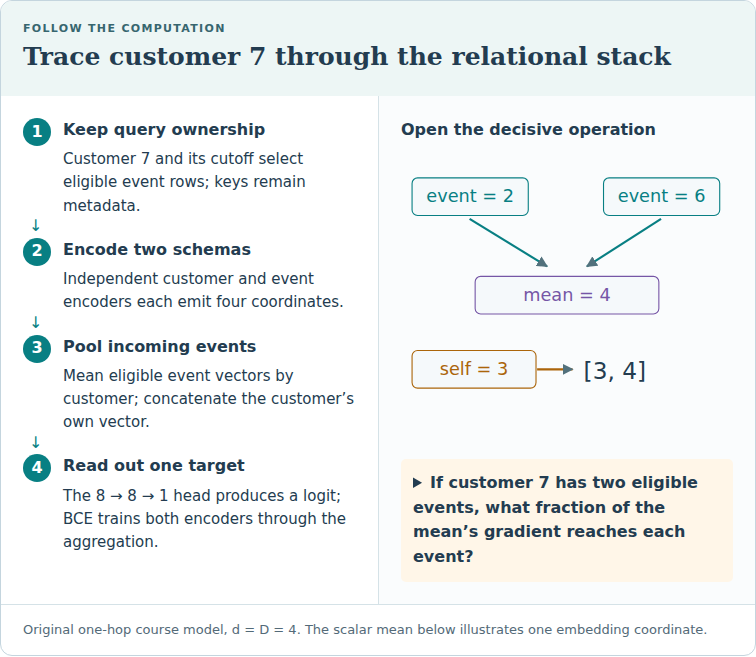

Original one-hop course model, d = D = 4. The scalar mean below illustrates one embedding coordinate.

**Trace question:** If customer 7 has two eligible events, what fraction of the mean’s gradient reaches each event?

**Trace answer:** One half of each arriving coordinate gradient, before the event encoder’s own derivatives. Excluded events have no path.

**Skill:** connect real typed row encoders to a manual one-hop aggregate and trainable head. TierC fixture; no benchmark claim. The optional historical RelBench experiment follows EXIT. Read the portable lesson, implement three TODOs, run CHECKs and export the trace.

Lesson · Reproduction contract

### Running on Google Colab?

Colab opens only this single file, so the course package (`relkit`) and the lab dependencies (xgboost, lightgbm, catboost, …) are **not** present by default. The cell below fixes that: on Colab it shallow-clones the course repo, installs `requirements-labs.txt`, and switches into `labs/` so `relkit` imports and the data cache resolve. **On a local venv or your own Jupyter it does nothing — just run it and continue.**

```python
# @colab-bootstrap — PROVIDED. Makes the lab self-sufficient on Google Colab; a no-op elsewhere.
import os, sys

if "google.colab" in sys.modules:
    if not os.path.isdir("/content/relational"):
        !git clone --depth 1 https://github.com/Avistian/relational.git /content/relational
    %pip install -q -r /content/relational/requirements-labs.txt
    os.chdir("/content/relational/labs")
    print("Colab ready — working dir:", os.getcwd())
else:
    print("Not on Colab — using the local environment as-is.")
```

```python
# PROVIDED — default lab is pinned to the L075 API. Historical replay uses an isolated interpreter.
import importlib.metadata
assert importlib.metadata.version('pytorch-frame') == '0.3.0'
```

**Your tangible win.** Build a complete two-table predictor and account for every input coordinate, edge and gradient. You will connect the row encoder from Lesson 75 to another table, rather than treating relational learning as an unexplained box. This is the architecture preview specified by the curriculum. The core lab takes about an hour; the historical benchmark replay is a separate, longer track.

THE BIG PICTURE · LESSON 076

**Build on what you know.** [Lesson 75](https://avistian.github.io/relational/lessons/0075-pytorch-frame-row-encoder.html) ended at one vector per record. [Lesson 55](https://avistian.github.io/relational/lessons/0055-tabred-temporal-splits.html) supplied point-in-time discipline. Combining these requires two explicit operations: connect identities correctly and remove information that was not available at prediction time.

**The next question.** [Lesson 77](https://avistian.github.io/relational/lessons/0077-single-table-ceiling.html) asks what the relational route can preserve that a chosen flattened summary loses. [Lesson 78](https://avistian.github.io/relational/lessons/0078-message-passing-preview.html) turns this concrete one-hop stack into the message-passing vocabulary.

[Open the SSL → relational → graph model map](https://avistian.github.io/relational/reference/0071-0090-model-map.html) · Spend 15–20 minutes tracing this overview before the detailed mechanism and lab.

## Follow one customer from rows to loss

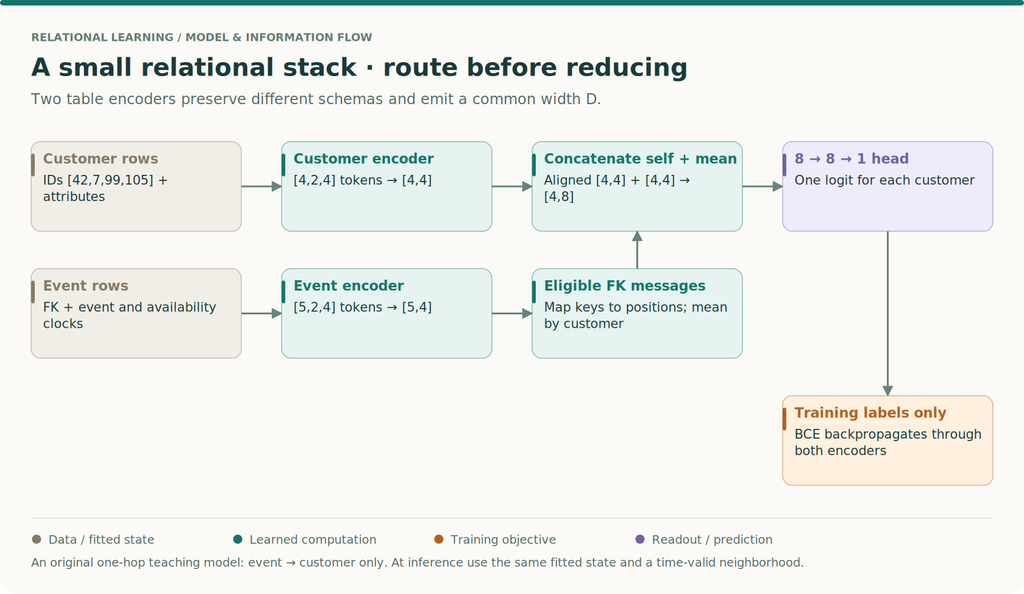

Read the arrows as data dependencies. Teal: learned computation; amber: training objective; violet: readout or prediction. This is a computation overview; exact settings and paper/release differences are specified below.

### Read for the boundary between modules

Revisit [PyTorch Frame Figure 1](https://arxiv.org/html/2404.00776v2), then the task and graph setup in [RelBench](https://arxiv.org/html/2407.20060v1). The small stack here is a teaching construction. Its purpose is to make the row-encoder → relation-aggregation → prediction interface visible before inspecting the larger historical model later in the lesson.

### Work a complete one-hop prediction

1. **Encode each table independently.** A customer vector and an event vector can both have width D=4 while using different statistics, vocabularies and weights. Equal width makes messages composable; it does not make the two schemas equivalent.
2. **Resolve keys to positions.** If customers are stored as [42,7,99,105], an event with FK=7 routes to tensor position 1. Keep this mapping beside the tensors. A valid tensor shape cannot detect a mistaken identity mapping.
3. **Apply the availability rule.** An event dated before prediction time can still be unavailable if it was recorded later. Test the event and availability clocks against the declared cutoff before aggregating. The exact inequality belongs to the task contract.
4. **Reduce only eligible messages.** In a two-coordinate hand example, customer 7 receives [2,4] and [6,0]. Its mean neighbor message is [4,2]. If the second event is unavailable, the message becomes [2,4], not [1,2]; the denominator counts eligible events only.
5. **Join representations and predict.** If its own state is [1,3], concatenate [1,3,4,2]. For a toy head w=[1,0,−0.5,0] with zero bias, the logit is −1 and sigmoid is about 0.269. This illustrative head is smaller than the actual nonlinear notebook head, but exposes the same alignment requirement.
6. **Trace the gradient backward.** Customer supervision changes the prediction head, then both the own-row path and eligible event path. An event need not have its own target to receive a learning signal through a supervised customer's prediction.

**Predict: what changes if an unrelated customer's event is modified?**

In this one-hop model it must not change the first customer's prediction, provided fitted preprocessing is held fixed. A change would suggest incorrect routing, reduction across the whole batch, or unintended shared query statistics.

**Your intermediate artifact:** record one prediction's customer ID, eligible event IDs, encoded messages, reducer denominator and logit. This trace is a stronger debugging artifact than a training-loss plot alone.

## 1. Why the row encoder needs a neighbor

> **In plain terms.** A customer row describes the customer. Purchase rows describe what the customer did. A relational predictor needs a controlled way to bring those descriptions together.

A **table** contains records with named columns. A **primary key**, or PK, identifies a record uniquely within a table. A **foreign key**, or FK, points to a primary key in another table. These keys define relationships. They do not say that larger IDs mean greater amounts or more important customers.

A **row encoder** is a learned function that maps the descriptive features of one record to a vector of numbers. A vector coordinate has no predetermined business meaning; training adjusts coordinates to support the prediction task. **Message passing** lets one record receive information from related records. An **aggregation** combines a variable number of incoming vectors into one fixed-width vector. A **head** maps the resulting representation to the task's output.

PyTorch Frame separates typed input conversion, column encoding, within-row interaction and readout. Its row representations can feed a graph model. Read the [primary paper's Figure 1 and §3](https://arxiv.org/html/2404.00776v2) with one question: where does within-row computation end? That boundary is where this lesson begins.

**The distinction that matters.** Mixing age and region within a customer row is column interaction. Combining that customer's purchase records is cross-row message passing. A very sophisticated row encoder still cannot use a purchase it never receives.

## 2. Model architecture: a complete, small RDL stack

**RDL** means relational deep learning: learning representations and predictions using records and their relationships. Our pictured variant has two table-specific encoders, one direction of communication, one aggregation step, and a binary prediction head. **One hop** means a message traverses one relationship. There is no recurrent update and no hidden second hop.

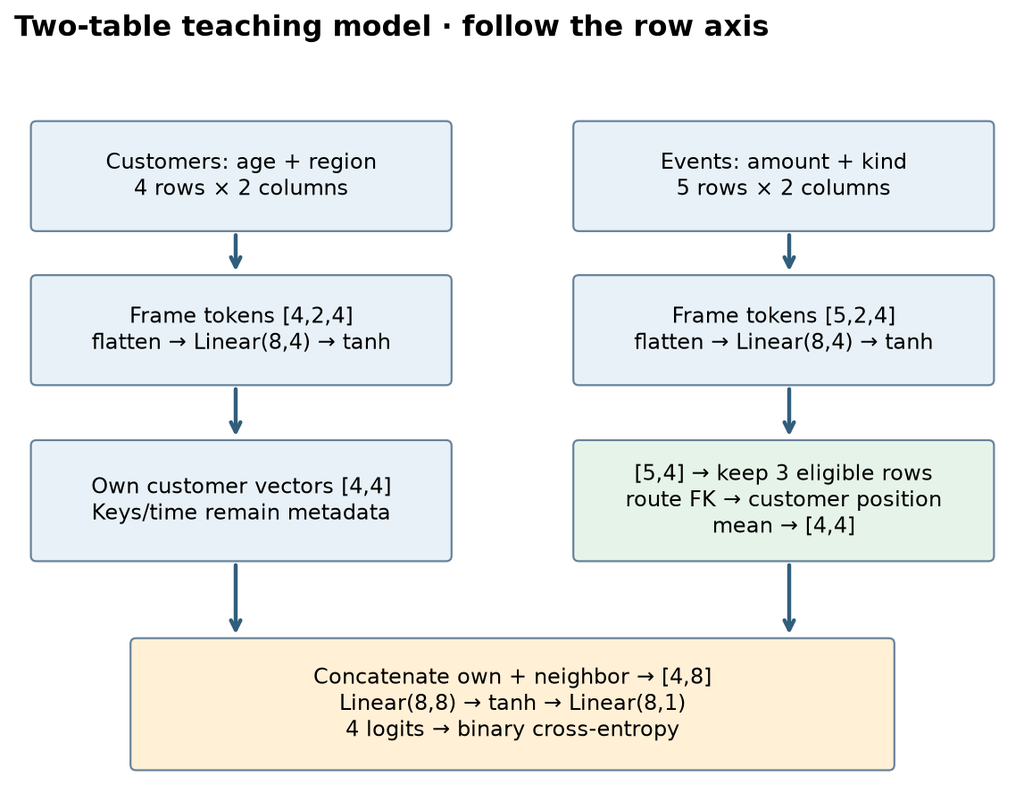

Complete teaching variant: two independent Frame encoders, one eligible event-to-customer hop, mean, concatenation and binary head. d=D=4; keys are metadata.

**Read the shapes.** `[N,C,d]` means N rows, C columns per row, and d encoded coordinates per column. The customer feature table has 4 rows and 2 columns. With d=4, its tokens are `[4,2,4]`. Flattening the last two axes gives `[4,8]`. A learned linear projection and a bounded activation, `tanh`, produce `[4,4]` customer vectors. The event encoder follows the same pattern for 5 event rows, producing `[5,4]` vectors. The encoders have separate weights even though these example schemas have the same number of columns.

**Why separate encoders?** A region category and a purchase kind are different vocabularies. A customer's age and an event's amount have different statistics. The shared contract is the output width D=4, not shared feature semantics. Another encoder could replace either one if it preserves its row identities, output width, device, numeric type and gradient connection.

**The final connection.** Aggregating events creates `[4,4]` neighbor vectors aligned to customers. Concatenation places each customer's own four coordinates beside its four neighbor coordinates, producing `[4,8]`. The head applies a learned 8→8 transformation, `tanh`, and an 8→1 transformation. Removing the singleton last axis returns four **logits**, shape `[4]`. A logit is an unconstrained score; the sigmoid function converts it to a number between zero and one. That number is not automatically calibrated.

> **Scope check.** This is a complete teaching model, not a new architecture paper or the RelBench benchmark model. Its actual PyTorch Frame encoders are the API under study. Key routing, temporal eligibility, reduction, composition and training are visible in the notebook. The historical RelBench model and trainer are shown separately after EXIT.

## 3. Identity comes before arithmetic

**Worked example.** The customer IDs, in their current table order, are `[42, 7, 99, 105]`. The event foreign keys are `[7, 42, 7, 99, 42]`. Therefore the destination row positions are `[1, 0, 1, 2, 0]`. The first event belongs to customer 7, which occupies row position 1.

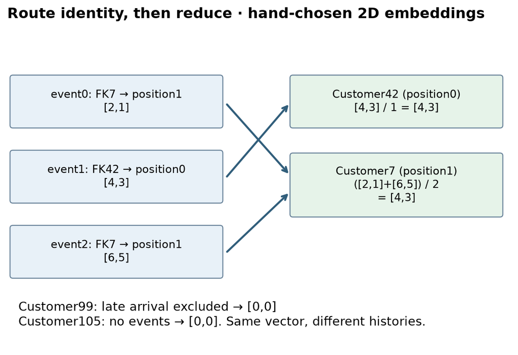

Illustrative width-2 embeddings, distinct from learned width-4 rows. Customers42 and7 have equal means despite different histories. Event3 arrives late; event4 is in the future.

A **graph node** is a record. A directed **edge** specifies which record sends to which receiver. Here an event sends to its customer. A relationship in a database does not force a graph's communication direction: a model designer chooses it. A reverse edge would let a customer send to an event, and a second hop could then carry information farther. This lab deliberately has neither.

**Failure case.** Using the FK value 42 directly as a tensor index is wrong for a four-row table. Subtracting the smallest ID is still wrong because IDs are not contiguous. Sorting customers without updating destinations silently routes messages to the wrong people. Both tensors may retain perfectly valid shapes.

**A stronger check than shape.** Permute customer rows, rebuild the ID-to-position mapping, and verify that predictions move with customer identities. Independently permute events and their edge metadata. A mean reduction should give the same prediction, up to floating-point roundoff. These are **equivariance** and **invariance** checks: an output ordering changes appropriately under the first transformation, while numeric outputs stay fixed under the second.

**Check yourself: customer order becomes [99,42,105,7]. Where does FK 7 go?**

Position 3. The entity remains customer 7. Position is a property of the current tensor layout, not the database identity.

## 4. Time decides whether an edge can carry information

> **In plain terms.** An old event recorded tomorrow was not available for today's prediction.

A **prediction cutoff** is the moment at which the model must make its decision. An **event time** records when something happened. An **availability time** records when the feature became accessible to the predictor. They can differ because records arrive late. The lab uses integer days and an inclusive boundary: both times must be less than or equal to day 10. In a real application, the boundary convention must match the task.

Our first three events are visible. The fourth occurred on day 4 but became available on day 11, so it is excluded. The fifth occurred and arrived on day 12, so it is also excluded. The corresponding mask is `[true,true,true,false,false]`.

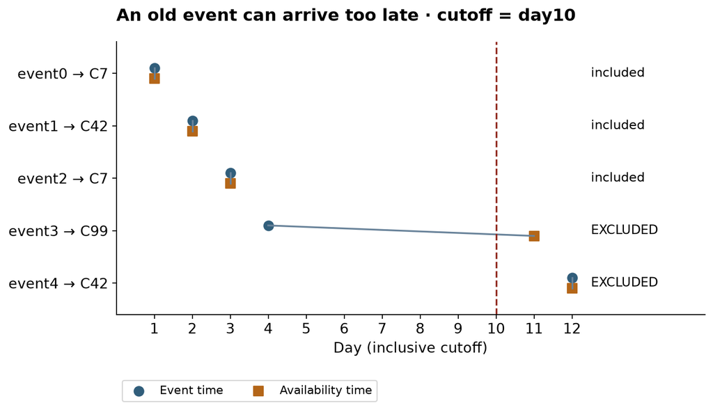

Day10 cutoff: event3 happened on day4 but arrived on day11. Event4 is later still. Both are excluded; the first three events are eligible.

**Two distinct leakage paths.** Filtering edges prevents an unavailable event vector from directly reaching a customer. It does not prevent unavailable raw values from influencing a fitted mean, vocabulary or normalization statistic. The lab therefore fits event materialization on eligible rows, then converts all rows using that frozen state. Changing only excluded amounts must leave both fitted state and predictions unchanged.

**Why convert excluded rows at all?** This small fixture keeps all five rows to make masking and gradient checks inspectable. Its encoder is row-local. A batch-dependent normalization across all events would reintroduce influence before masking; it would require a different treatment. At scale, filter or sample eligible rows before encoding them.

**What is held fixed?** Customer attributes are assumed already available at day 10. The fixture has one snapshot and no held-out data. For a predictive benchmark, fit data-dependent state only on the training information allowed by the protocol, then enforce each query's own cutoff. A single global mask is insufficient when queries have different times.

**Check yourself: is event_day≤cutoff enough?**

No. It admits late-arriving records. In this fixture the day-4 event is unavailable until day 11. Feature revisions and label availability also need their own audit in a real task.

## 5. Compute one hop, coordinate by coordinate

**Worked example.** To expose the arithmetic, temporarily use two-dimensional illustrative event embeddings. These are hand-chosen values, not the trained width-4 encoder output. The first three events encode as `[2,1]`, `[4,3]`, and `[6,5]`. Their destination positions are `[1,0,1]`.

Customer 42 receives `[4,3]`, so its mean is `[4,3]`. Customer 7 receives two vectors. Add them coordinatewise to get `[8,6]`, then divide by two to get `[4,3]`. Customers 99 and 105 have no eligible events. Their neighbor vectors are explicitly defined as `[0,0]`.

**The general rule.** Write z_j for event j's vector and N(i,t) for the set of events linked to customer i and available at cutoff t. The count n_i is the number of events in that set. The neighbor vector is:

```
m_i = sum(z_j for j in N(i,t)) / max(n_i, 1)
```

The sum over an empty set is a zero vector. The denominator guard makes the empty case finite; it does not invent a neighbor. The implementation accumulates messages using indexed addition. Repeated destinations must add their contributions. Assigning values directly into destination slots would overwrite earlier events and teach the wrong operation.

**A mean loses information.** One `[4,3]` and the mean of `[2,1]` plus `[6,5]` collide. Both produce `[4,3]` despite different event counts. A sum produces `[4,3]` versus `[8,6]`, preserving this particular distinction but making scale depend on count. Concatenating the count is another design option. Neither choice is universally superior. Our head receives the mean but not the count; the returned count is an audit artifact.

**An empty-neighborhood collision.** No events and a real event whose embedding is exactly zero both give a zero aggregate. Own-row features still let the head make a prediction, but cannot recover the missing neighborhood distinction by themselves. A learned empty token or an explicit count could expose it.

**Why the dense oracle helps.** Build an incidence matrix A with one column per eligible event and one row per customer. Entry A[i,j]=1 when event j routes to customer i, otherwise zero. Multiplying A by the event matrix sums each customer's messages. Dividing each row by its count gives an independent expression for the same result. The verifier compares both values and derivatives to this oracle, then compares the mean primitive to a configured PyG SAGEConv with identity neighbor weights and no root contribution.

> **Scope check.** The primitive comparison verifies this reduction. It does not establish equivalence between the complete toy predictor and GraphSAGE or RelBench.

## 6. The head sends a learning signal back across the join

> **In plain terms.** A prediction error can change how a purchase is encoded, even though the prediction is attached to the customer.

**Training objective.** A binary target is 0 or 1. Binary cross-entropy penalizes confident wrong predictions. The notebook uses the numerically stable logits form, `binary_cross_entropy_with_logits`, without first applying sigmoid. The optimizer, Adam, adjusts learned parameters using the derivative of the loss. A **gradient** tells us how a small parameter change would change that loss locally.

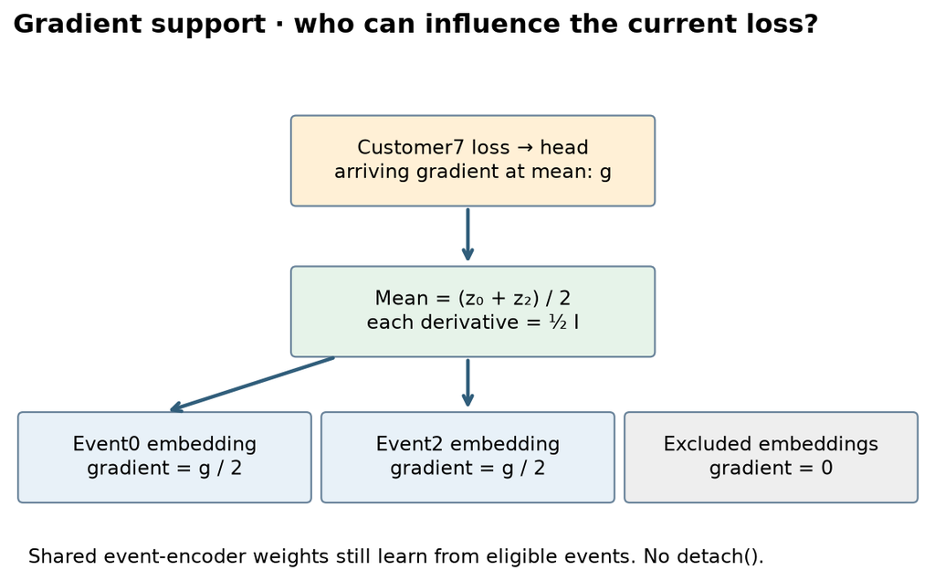

Backward trace for customer7 with two eligible events. I denotes the identity matrix; each message receives one half of the arriving derivative. Excluded event embeddings have no loss path.

**Trace the derivative.** If customer 7 has two eligible events, each receives one half of the gradient arriving at their mean vector. The head and event encoder contribute further derivatives. With only one eligible event, that event receives the full aggregate derivative. Excluded event embeddings receive zero gradient through this path. They do not receive a message simply because they were materialized.

**Complete the opening trace with a real derivative.** Return to the illustrative events `[2,4]` and `[6,0]`, mean `[4,2]`, own state `[1,3]` and head `[1,0,−0.5,0]`. The logit was −1. For target y=1, binary cross-entropy is `log(1+exp(1)) ≈ 1.3133`, and its derivative with respect to the logit is `sigmoid(−1)−1 ≈ −0.7311`. Multiply by the head's neighbor weight −0.5: the first mean coordinate receives gradient +0.3655. Divide across its two events: each first event coordinate receives **+0.1828**; each second coordinate receives 0 because this illustrative head ignores it.

| Backward location | First-coordinate derivative |
| --- | --- |
| Neighbor mean | +0.3655 |
| Event 1 | +0.1828 |
| Event 2 | +0.1828 |

A gradient-descent step subtracts this positive derivative. Lower event coordinates reduce the mean, raise the logit through its negative head weight, and reduce the positive-label loss. **Try it:** exclude the second event and recompute the forward pass before differentiating. The new mean is `[2,4]`, logit 0 and loss 0.6931; the sole event receives gradient +0.25. It is not simply twice +0.1828, because changing eligibility also changed the prediction and hence the upstream derivative.

**An important distinction.** Encoder weights are shared across events within a table. Training on visible events can change how an excluded event would be encoded in a later forward pass. That does not mean the excluded event supplied information to the current loss. The verifier checks gradient support on individual event embeddings, not an incorrect requirement that their shared weights never change.

**The accidental break.** Calling `detach()`, converting learned vectors to NumPy, or saving fixed embeddings before fitting only the head prevents loss derivatives from reaching upstream encoders. Frozen features can be an intentional baseline. They are not end-to-end training. The lab asserts nonzero finite gradients in both encoders and in the head.

## 7. Execute the diagnostic and interpret it honestly

**Before running.** Predict whether the model can reduce loss on four labeled rows, and whether that establishes anything about unseen customers. The labels are arbitrary fixture labels, never included in feature materialization. We fix seed 76, use full-batch Adam with learning rate 0.03, and run 100 updates. No validation selection takes place.

**Author-reference evidence — measured locally, not your current kernel output.**

| Measurement | Observed | Interpretation |
| --- | --- | --- |
| First / final training loss | 0.681352 / 0.000726 | Four-row overfit diagnostic only |
| Counts in customer order [42,7,99,105] | [1, 2, 0, 0] | Late and future events excluded |
| Customer / event row vectors | [4,4] / [5,4] | Actual PyTorch Frame path |
| Concatenated / logit shape | [4,8] / [4] | One prediction per customer |
| PyG mean primitive maximum error | 0.0e+00 | Primitive forward parity |
| Key/time/gradient/permutation checks | PASS | See saved verifier report |
| Historical RelBench training | NOT_RUN | No measured paper AUROC |

**Held fixed / varied / measured.** Architecture, data and labels stay fixed. The optimizer varies the weights. We measure the loss on the same four rows used to fit them. Loss reduction confirms an executable differentiable path with enough capacity to fit this fixture. A constant-label predictor, a tiny head-only model or memorization may also fit tiny data. This diagnostic does not measure generalization, relational advantage or paper reproducibility.

**What the tests contribute.** Loss alone could fall with misrouted edges. Key remapping tests catch that. Loss alone could fall with future leakage. The excluded-value intervention catches that. Loss alone could fall with frozen encoders. Gradient checks catch that. A useful verification suite tests the behavior the lesson claims, not merely whether Python finished.

## 8. Your lab: three load-bearing repairs

Open the companion notebook. It contains the complete architecture and training loop in readable cells. Implement three functions: **key_positions**, **eligible_events**, and **mean_messages**. Each is called by the live pipeline. Each has an immediate CHECK that fails for a meaningful mistake. Complete the functions before consulting the solution notebook.

**EXIT deliverable.** Export a JSON trace with tensor shapes, eligible counts, seed and measured loss. Submit it with a short explanation of why customer 99 has no eligible events, why customer 7 receives half-gradients per event, and what evidence would be necessary to claim a relational performance benefit. Re-run after permuting customer rows and remapping keys. Predict the outcome before executing.

**Retrieval tomorrow.** Draw the stack from memory. Label where a vocabulary is fitted, where a PK becomes a tensor index, where time removes an edge, and where the task loss enters. Ask the teaching agent to quiz you on the weakest step; paste your EXIT explanation for feedback.

## 9. Historical reproduction: from this skeleton to RelBench

The optional target is **RelBench v1, Table 6, rel-f1 / driver-dnf**. The published test AUROC mean is **72.62%**, over five runs. AUROC measures ranking across positive and negative examples; it is not threshold accuracy. The paper uses two GNN layers, width 128, summation, batch size 512, learning rate 0.005 and up to 10 epochs for this task. See the [primary experiment and Appendix B](https://arxiv.org/html/2407.20060v1).

The archived code is the publication-day revision `5894184f3d1b2432feb9a208a8aaf18b106fbdf4`. Its complete model, heterogeneous encoder, temporal encoder, GraphSAGE blocks and training script appear after EXIT in the notebook. It adds learned relative-time features and temporal neighborhood sampling. It uses validation AUROC to select the checkpoint before final test evaluation. The toy model's mean and shallow head cannot stand in for this experiment.

**A concrete mismatch to diagnose.** The released loader calculates fanouts as `[128,64]` when asked for 128 neighbors and two layers. The paper describes a maximum of 128 neighbors per foreign key. The replay preserves the released code and records that distinction. We choose seeds 0–4; the precise published seed list was not identified. Source identity, environment pins, text-model download, dataset versions and protocol differences belong in the reproduction contract.

> **Scope check.** Full benchmark training is **NOT_RUN**. This WSL machine has an ARM CPU environment without the historical temporal sampling stack. The local preflight records the blocker rather than running a modified current implementation. CLI, isolated Colab and Modal operators accompany the full archived code. Their availability is not evidence of completed cloud execution or paper-result parity. Consult the contract for the exact remaining gaps and run commands.

**The next conceptual step.** Curriculum L077 tests what rows-only information cannot express. L078 develops message passing itself. In later RDL work this same separation—encode records, exchange eligible messages, predict a target—will let you change one component while keeping the experiment interpretable.

## Implement the live stack

The following cells contain the complete teaching implementation. No model is hidden behind a relkit import. In particular, materialize_tables and RelationalStack call your live functions. Run locally with the working directory set to labs/.

```python
import pandas as pd
import torch
from torch import nn
from torch_frame import stype, NAStrategy
from torch_frame.data import Dataset
from torch_frame.nn import StypeWiseFeatureEncoder, LinearEncoder, EmbeddingEncoder
import json
from pathlib import Path
torch.set_num_threads(1)
torch.manual_seed(76)
```

### PROVIDED · exact fixture

Four customer identities and five events. Customer99 has an event, but it is unavailable at day10. Customer105 has none. Labels are diagnostic targets only.

```python
def fixture():
    customers = pd.DataFrame({'customer_id':[42,7,99,105],
                              'age':[20.,40.,30.,50.],
                              'region':['north','south','north','south']})
    events = pd.DataFrame({'customer_id':[7,42,7,99,42],
                           'amount':[2.,4.,6.,8.,100.],
                           'kind':['buy','buy','return','buy','buy'],
                           'event_day':[1,2,3,4,12],
                           'available_day':[1,2,3,11,12]})
    # Label toy: arbitrary diagnostic targets; never used as features or fitted state.
    return customers, events, torch.tensor([0.,1.,0.,1.])
```

### TODO · key_positions

Return a LongTensor of destination positions, preserving foreign-key order. Reject nonunique primary keys and unknown foreign keys. Why: valid shapes cannot prove correct identity.

Write your expected output before running the CHECK.

```python
def key_positions(primary_keys, foreign_keys):
    raise NotImplementedError("Implement key_positions")
```

```python
# CHECK — do not edit
assert key_positions([42,7,99,105],[7,42,7,99,42]).tolist()==[1,0,1,2,0], 'Map identities, not values or sort order'
assert key_positions([99,42,105,7],[7,42]).tolist()==[3,1]
for pk,fk in [([1,1],[1]),([1],[2])]:
    try: key_positions(pk,fk)
    except ValueError: pass
    else: raise AssertionError('Reject duplicate PKs and dangling FKs')
print('CHECK: key identity and integrity pass')
```

### TODO · eligible_events

Return a boolean mask using event and availability days and the inclusive cutoff. Why: late-arriving history is not usable merely because its event time is old.

Write your expected output before running the CHECK.

```python
def eligible_events(event_day, available_day, cutoff):
    raise NotImplementedError("Implement eligible_events")
```

```python
# CHECK — do not edit
actual = eligible_events(torch.tensor([1,2,3,4,12]),torch.tensor([1,2,3,11,12]),10)
assert actual.tolist()==[True,True,True,False,False], 'An old event can arrive late'
assert eligible_events(torch.tensor([10]),torch.tensor([10]),10).item(), 'Inclusive boundary'
print('CHECK: availability and inclusive cutoff pass')
```

### TODO · mean_messages

Return differentiable per-destination means and integer counts. Handle repeated destinations and empty groups. Why: this operation determines both information access and gradient allocation.

Write your expected output before running the CHECK.

```python
def mean_messages(messages, destination, num_destinations):
    raise NotImplementedError("Implement mean_messages")
```

```python
# CHECK — do not edit
m = torch.tensor([[2.,1.],[4.,3.],[6.,5.]],requires_grad=True)
a,n = mean_messages(m,torch.tensor([1,0,1]),4)
assert torch.equal(a,torch.tensor([[4.,3.],[4.,3.],[0.,0.],[0.,0.]])), 'Repeated destinations must accumulate'
assert n.tolist()==[1,2,0,0], 'Count eligible events per receiver'
a[1].sum().backward()
assert torch.equal(m.grad,torch.tensor([[.5,.5],[0.,0.],[.5,.5]])), 'Do not detach messages'
empty,count = mean_messages(m[:0],torch.empty(0,dtype=torch.long),4)
assert torch.equal(empty,torch.zeros(4,2)) and not count.any()
print('CHECK: means, empty groups and gradients pass')
```

### PROVIDED · materialize_tables

Keep key/time columns outside input features. Fit event statistics only on allowed records, then reuse the converter.

```python
def materialize_tables(customers, events, cutoff=10):
    """PK/FK/time/labels stay outside feature tables. Fit only visible event rows.

    Customer attributes are assumed observed before the cutoff. This fixed-snapshot
    diagnostic has no held-out split. A predictive experiment needs train-only fitting.
    """
    destination = key_positions(customers.customer_id.tolist(), events.customer_id.tolist())
    mask = eligible_events(torch.tensor(events.event_day.to_numpy()),
                           torch.tensor(events.available_day.to_numpy()), cutoff)
    customer_ds = Dataset(customers[['age','region']],
                          col_to_stype={'age':stype.numerical,'region':stype.categorical})
    event_ds = Dataset(events.loc[mask.numpy(), ['amount','kind']].copy(),
                       col_to_stype={'amount':stype.numerical,'kind':stype.categorical})
    customer_ds.materialize(); event_ds.materialize()
    # Conversion of all rows uses frozen visible-row state, not a new fit.
    all_events = event_ds.convert_to_tensor_frame(events[['amount','kind']])
    return customer_ds, event_ds, all_events, destination, mask
```

### PROVIDED · TableEncoder

The library provides typed encoders. The projection/readout is visible. Separate instances give each table its own learned parameters.

```python
class TableEncoder(nn.Module):
    """Real Frame typed tokens [N,C,d] → flattened projection [N,D]."""
    def __init__(self, dataset, width=4):
        super().__init__()
        self.columns = StypeWiseFeatureEncoder(
            out_channels=width, col_stats=dataset.col_stats,
            col_names_dict=dataset.tensor_frame.col_names_dict,
            stype_encoder_dict={stype.numerical:LinearEncoder(na_strategy=NAStrategy.MEAN),
                                stype.categorical:EmbeddingEncoder()})
        self.readout = nn.Sequential(nn.Flatten(1),
                                    nn.Linear(dataset.tensor_frame.num_cols*width,width),nn.Tanh())

    def forward(self, tf):
        tokens, _ = self.columns(tf)
        return self.readout(tokens)
```

### PROVIDED · RelationalStack

Trace encoder → eligible gather → your mean function → concatenate → head. The returned trace exposes every boundary.

```python
class RelationalStack(nn.Module):
    """One direction, one hop, mean reduction, concatenation and binary head.

    Separate encoders allow different schemas. The head is the update/predictor;
    this is not the two-layer heterogeneous GraphSAGE used by RelBench.
    """
    def __init__(self, customer_ds, event_ds, width=4):
        super().__init__()
        self.customer_encoder = TableEncoder(customer_ds,width)
        self.event_encoder = TableEncoder(event_ds,width)
        self.head = nn.Sequential(nn.Linear(2*width,8),nn.Tanh(),nn.Linear(8,1))

    def forward(self, customer_tf, event_tf, destination, eligible):
        customer_rows = self.customer_encoder(customer_tf)
        event_rows = self.event_encoder(event_tf)
        neighbors, counts = mean_messages(event_rows[eligible],destination[eligible],len(customer_tf))
        combined = torch.cat([customer_rows,neighbors],dim=1)
        logits = self.head(combined).squeeze(-1)
        return logits, {'customers':customer_rows,'events':event_rows,
                        'neighbors':neighbors,'counts':counts,'combined':combined}
```

### PROVIDED · run_diagnostic

Complete full-batch trainer. This is four-row overfitting, not held-out evaluation. The function resolves the live classes and TODOs above.

```python
def run_diagnostic(steps=100):
    """Overfit four rows: a wiring diagnostic, with NO held-out accuracy claim."""
    torch.set_num_threads(1); torch.manual_seed(76)
    customers, events, labels = fixture()
    cds, eds, etf, destination, mask = materialize_tables(customers,events)
    model = RelationalStack(cds,eds)
    optimizer = torch.optim.Adam(model.parameters(),lr=.03)
    losses=[]
    for step in range(steps):
        optimizer.zero_grad()
        logits, trace = model(cds.tensor_frame,etf,destination,mask)
        loss = nn.functional.binary_cross_entropy_with_logits(logits,labels)
        loss.backward();optimizer.step();losses.append(float(loss.detach()))
    with torch.no_grad():logits,trace=model(cds.tensor_frame,etf,destination,mask)
    return {'seed':76,'steps':steps,'first_loss':losses[0],
            'final_loss':float(nn.functional.binary_cross_entropy_with_logits(logits,labels)),
            'losses':losses,'shapes':{k:list(v.shape) for k,v in trace.items()},
            'counts':trace['counts'].tolist(),'logits':logits.tolist()}
```

### CHECK · future intervention and complete gradients

Predict whether changing excluded amounts can alter outputs. Notice that this check also refits allowed materialization state: edge filtering alone is not sufficient.

```python
customers,events,labels = fixture()
cd,ed,et,destination,mask = materialize_tables(customers,events)
model = RelationalStack(cd,ed)
logits,trace = model(cd.tensor_frame,et,destination,mask)
assert logits.shape==(4,) and trace['combined'].shape==(4,8)
changed=events.copy();changed.loc[~mask.numpy(),'amount']=1e8
cd2,ed2,et2,d2,m2=materialize_tables(customers,changed)
assert ed.col_stats==ed2.col_stats
assert torch.equal(logits,model(cd2.tensor_frame,et2,d2,m2)[0])
trace['events'].retain_grad()
nn.functional.binary_cross_entropy_with_logits(logits,labels).backward()
assert torch.equal(trace['events'].grad[~mask],torch.zeros_like(trace['events'].grad[~mask]))
for block in [model.customer_encoder,model.event_encoder,model.head]:
    gradients=[p.grad for p in block.parameters() if p.grad is not None]
    assert gradients and all(torch.isfinite(g).all() for g in gradients)
    assert sum(g.abs().sum() for g in gradients)>0
print('CHECK: future invariance and complete gradient path pass')
```

### EXIT · export evidence and explain its limits

Run the diagnostic, then save its result. In your own words: (1) why does customer99 receive zero neighbors; (2) where does each one-half gradient arise; (3) what else is needed before calling this a useful predictor? The saved file does not grade your written explanation.

```python
result=run_diagnostic()
assert result['final_loss'] < result['first_loss']/10
Path('l076-student-results.json').write_text(json.dumps(result,indent=2)+'\n')
print('Shapes:',result['shapes'])
print('Counts:',result['counts'])
print('Loss:',result['first_loss'],'→',result['final_loss'])
```

### EXIT · your explanation

Write your answer here. Then permute customer rows and rebuild the key mapping. Explain the relationship between the old and new predictions before running them. Send the trace and your explanation to the teaching agent for grading.

## NEXT STEP · full historical model and trainer

**NOT_RUN locally.** Target: RelBench v1 Table6 rel-f1/driver-dnf. This is a separate model from the toy. The following complete archived files are shown as source references; the gated operator executes these same pinned files in an isolated environment. Do not execute fragments in the default Frame0.3.0 kernel. Read the MIT license at the end of this appendix.

Protocol, environment, commands and deviations

### Archived relbench/modeling/nn.py

Table-specific ResNet encoders, relative-time encoders and heterogeneous GraphSAGE layers.

```
from typing import Any, Dict, List, Optional

import torch
import torch_frame
from torch import Tensor
from torch_frame.data.stats import StatType
from torch_frame.nn.models import ResNet
from torch_geometric.nn import HeteroConv, LayerNorm, PositionalEncoding, SAGEConv
from torch_geometric.typing import EdgeType, NodeType


class HeteroEncoder(torch.nn.Module):
    r"""HeteroEncoder based on PyTorch Frame.

    Args:
        channels (int): The output channels for each node type.
        node_to_col_names_dict (Dict[NodeType, Dict[torch_frame.stype, List[str]]]):
            A dictionary mapping from node type to column names dictionary
            compatible to PyTorch Frame.
        torch_frame_model_cls: Model class for PyTorch Frame. The class object
            takes :class:`TensorFrame` object as input and outputs
            :obj:`channels`-dimensional embeddings. Default to
            :class:`torch_frame.nn.ResNet`.
        torch_frame_model_kwargs (Dict[str, Any]): Keyword arguments for
            :class:`torch_frame_model_cls` class. Default keyword argument is
            set specific for :class:`torch_frame.nn.ResNet`. Expect it to
            be changed for different :class:`torch_frame_model_cls`.
        default_stype_encoder_cls_kwargs (Dict[torch_frame.stype, Any]):
            A dictionary mapping from :obj:`torch_frame.stype` object into a
            tuple specifying :class:`torch_frame.nn.StypeEncoder` class and its
            keyword arguments :obj:`kwargs`.
    """

    def __init__(
        self,
        channels: int,
        node_to_col_names_dict: Dict[NodeType, Dict[torch_frame.stype, List[str]]],
        node_to_col_stats: Dict[NodeType, Dict[str, Dict[StatType, Any]]],
        torch_frame_model_cls=ResNet,
        torch_frame_model_kwargs: Dict[str, Any] = {
            "channels": 128,
            "num_layers": 4,
        },
        default_stype_encoder_cls_kwargs: Dict[torch_frame.stype, Any] = {
            torch_frame.categorical: (torch_frame.nn.EmbeddingEncoder, {}),
            torch_frame.numerical: (torch_frame.nn.LinearEncoder, {}),
            torch_frame.multicategorical: (
                torch_frame.nn.MultiCategoricalEmbeddingEncoder,
                {},
            ),
            torch_frame.embedding: (torch_frame.nn.LinearEmbeddingEncoder, {}),
            torch_frame.timestamp: (torch_frame.nn.TimestampEncoder, {}),
        },
    ):
        super().__init__()

        self.encoders = torch.nn.ModuleDict()

        for node_type in node_to_col_names_dict.keys():
            stype_encoder_dict = {
                stype: default_stype_encoder_cls_kwargs[stype][0](
                    **default_stype_encoder_cls_kwargs[stype][1]
                )
                for stype in node_to_col_names_dict[node_type].keys()
            }
            torch_frame_model = torch_frame_model_cls(
                **torch_frame_model_kwargs,
                out_channels=channels,
                col_stats=node_to_col_stats[node_type],
                col_names_dict=node_to_col_names_dict[node_type],
                stype_encoder_dict=stype_encoder_dict,
            )
            self.encoders[node_type] = torch_frame_model

    def reset_parameters(self):
        for encoder in self.encoders.values():
            encoder.reset_parameters()

    def forward(
        self,
        tf_dict: Dict[NodeType, torch_frame.TensorFrame],
    ) -> Dict[NodeType, Tensor]:
        x_dict = {
            node_type: self.encoders[node_type](tf) for node_type, tf in tf_dict.items()
        }
        return x_dict


class HeteroTemporalEncoder(torch.nn.Module):
    def __init__(self, node_types: List[NodeType], channels: int):
        super().__init__()

        self.encoder_dict = torch.nn.ModuleDict(
            {node_type: PositionalEncoding(channels) for node_type in node_types}
        )
        self.lin_dict = torch.nn.ModuleDict(
            {node_type: torch.nn.Linear(channels, channels) for node_type in node_types}
        )

    def reset_parameters(self):
        for encoder in self.encoder_dict.values():
            encoder.reset_parameters()
        for lin in self.lin_dict.values():
            lin.reset_parameters()

    def forward(
        self,
        seed_time: Tensor,
        time_dict: Dict[NodeType, Tensor],
        batch_dict: Dict[NodeType, Tensor],
    ) -> Dict[NodeType, Tensor]:
        out_dict: Dict[NodeType, Tensor] = {}

        for node_type, time in time_dict.items():
            rel_time = seed_time[batch_dict[node_type]] - time
            rel_time = rel_time / (60 * 60 * 24)  # Convert seconds to days.

            x = self.encoder_dict[node_type](rel_time)
            x = self.lin_dict[node_type](x)
            out_dict[node_type] = x

        return out_dict


class HeteroGraphSAGE(torch.nn.Module):
    def __init__(
        self,
        node_types: List[NodeType],
        edge_types: List[EdgeType],
        channels: int,
        aggr: str = "mean",
        num_layers: int = 2,
    ):
        super().__init__()

        self.convs = torch.nn.ModuleList()
        for _ in range(num_layers):
            conv = HeteroConv(
                {
                    edge_type: SAGEConv((channels, channels), channels, aggr=aggr)
                    for edge_type in edge_types
                },
                aggr="sum",
            )
            self.convs.append(conv)

        self.norms = torch.nn.ModuleList()
        for _ in range(num_layers):
            norm_dict = torch.nn.ModuleDict()
            for node_type in node_types:
                norm_dict[node_type] = LayerNorm(channels, mode="node")
            self.norms.append(norm_dict)

    def reset_parameters(self):
        for conv in self.convs:
            conv.reset_parameters()
        for norm_dict in self.norms:
            for norm in norm_dict.values():
                norm.reset_parameters()

    def forward(
        self,
        x_dict: Dict[NodeType, Tensor],
        edge_index_dict: Dict[NodeType, Tensor],
        num_sampled_nodes_dict: Optional[Dict[NodeType, List[int]]] = None,
        num_sampled_edges_dict: Optional[Dict[EdgeType, List[int]]] = None,
    ) -> Dict[NodeType, Tensor]:
        for _, (conv, norm_dict) in enumerate(zip(self.convs, self.norms)):
            x_dict = conv(x_dict, edge_index_dict)
            x_dict = {key: norm_dict[key](x) for key, x in x_dict.items()}
            x_dict = {key: x.relu() for key, x in x_dict.items()}

        return x_dict
```

### Archived examples/model.py

Complete forward composition, including seed-node readout and task head.

```
from typing import Any, Dict, List

import torch
from torch import Tensor
from torch.nn import Embedding, ModuleDict
from torch_frame.data.stats import StatType
from torch_geometric.data import HeteroData
from torch_geometric.nn import MLP
from torch_geometric.typing import NodeType

from relbench.modeling.nn import HeteroEncoder, HeteroGraphSAGE, HeteroTemporalEncoder


class Model(torch.nn.Module):

    def __init__(
        self,
        data: HeteroData,
        col_stats_dict: Dict[str, Dict[str, Dict[StatType, Any]]],
        num_layers: int,
        channels: int,
        out_channels: int,
        aggr: str,
        norm: str,
        # List of node types to add shallow embeddings to input
        shallow_list: List[NodeType] = [],
        # ID awareness
        id_awareness: bool = False,
    ):
        super().__init__()

        self.encoder = HeteroEncoder(
            channels=channels,
            node_to_col_names_dict={
                node_type: data[node_type].tf.col_names_dict
                for node_type in data.node_types
            },
            node_to_col_stats=col_stats_dict,
        )
        self.temporal_encoder = HeteroTemporalEncoder(
            node_types=[
                node_type for node_type in data.node_types if "time" in data[node_type]
            ],
            channels=channels,
        )
        self.gnn = HeteroGraphSAGE(
            node_types=data.node_types,
            edge_types=data.edge_types,
            channels=channels,
            aggr=aggr,
            num_layers=num_layers,
        )
        self.head = MLP(
            channels,
            out_channels=out_channels,
            norm=norm,
            num_layers=1,
        )
        self.embedding_dict = ModuleDict(
            {
                node: Embedding(data.num_nodes_dict[node], channels)
                for node in shallow_list
            }
        )

        self.id_awareness_emb = None
        if id_awareness:
            self.id_awareness_emb = torch.nn.Embedding(1, channels)
        self.reset_parameters()

    def reset_parameters(self):
        self.encoder.reset_parameters()
        self.temporal_encoder.reset_parameters()
        self.gnn.reset_parameters()
        self.head.reset_parameters()
        for embedding in self.embedding_dict.values():
            torch.nn.init.normal_(embedding.weight, std=0.1)
        if self.id_awareness_emb is not None:
            self.id_awareness_emb.reset_parameters()

    def forward(
        self,
        batch: HeteroData,
        entity_table: NodeType,
    ) -> Tensor:
        seed_time = batch[entity_table].seed_time
        x_dict = self.encoder(batch.tf_dict)

        rel_time_dict = self.temporal_encoder(
            seed_time, batch.time_dict, batch.batch_dict
        )

        for node_type, rel_time in rel_time_dict.items():
            x_dict[node_type] = x_dict[node_type] + rel_time

        for node_type, embedding in self.embedding_dict.items():
            x_dict[node_type] = x_dict[node_type] + embedding(batch[node_type].n_id)

        x_dict = self.gnn(
            x_dict,
            batch.edge_index_dict,
            batch.num_sampled_nodes_dict,
            batch.num_sampled_edges_dict,
        )

        return self.head(x_dict[entity_table][: seed_time.size(0)])

    def forward_dst_readout(
        self,
        batch: HeteroData,
        entity_table: NodeType,
        dst_table: NodeType,
    ) -> Tensor:
        if self.id_awareness_emb is None:
            raise RuntimeError(
                "id_awareness must be set True to use forward_dst_readout"
            )
        seed_time = batch[entity_table].seed_time
        x_dict = self.encoder(batch.tf_dict)
        # Add ID-awareness to the root node
        x_dict[entity_table][: seed_time.size(0)] += self.id_awareness_emb.weight

        rel_time_dict = self.temporal_encoder(
            seed_time, batch.time_dict, batch.batch_dict
        )

        for node_type, rel_time in rel_time_dict.items():
            x_dict[node_type] = x_dict[node_type] + rel_time

        for node_type, embedding in self.embedding_dict.items():
            x_dict[node_type] = x_dict[node_type] + embedding(batch[node_type].n_id)

        x_dict = self.gnn(
            x_dict,
            batch.edge_index_dict,
        )

        return self.head(x_dict[dst_table])
```

### Archived examples/text_embedder.py

The external GloVe adapter. Its checkpoint revision is a remaining reproducibility gap.

```
from typing import List, Optional

import torch

# Please run `pip install -U sentence-transformers`
from sentence_transformers import SentenceTransformer
from torch import Tensor


class GloveTextEmbedding:
    def __init__(self, device: Optional[torch.device] = None):
        self.model = SentenceTransformer(
            "sentence-transformers/average_word_embeddings_glove.6B.300d",
            device=device,
        )

    def __call__(self, sentences: List[str]) -> Tensor:
        return torch.from_numpy(self.model.encode(sentences))
```

### Archived examples/gnn_node.py

Complete original data preparation, temporal loaders, objective, training loop, checkpoint selection and final evaluation.

```
import argparse
import copy
import json
import math
import os
from pathlib import Path
from typing import Dict

import numpy as np
import torch
from model import Model
from text_embedder import GloveTextEmbedding
from torch.nn import BCEWithLogitsLoss, L1Loss
from torch_frame import stype
from torch_frame.config.text_embedder import TextEmbedderConfig
from torch_geometric.loader import NeighborLoader
from torch_geometric.seed import seed_everything
from tqdm import tqdm

from relbench.base import Dataset, EntityTask, TaskType
from relbench.datasets import get_dataset
from relbench.modeling.graph import get_node_train_table_input, make_pkey_fkey_graph
from relbench.modeling.utils import get_stype_proposal
from relbench.tasks import get_task

parser = argparse.ArgumentParser()
parser.add_argument("--dataset", type=str, default="rel-event")
parser.add_argument("--task", type=str, default="user-attendance")
parser.add_argument("--lr", type=float, default=0.005)
parser.add_argument("--epochs", type=int, default=10)
parser.add_argument("--batch_size", type=int, default=512)
parser.add_argument("--channels", type=int, default=128)
parser.add_argument("--aggr", type=str, default="sum")
parser.add_argument("--num_layers", type=int, default=2)
parser.add_argument("--num_neighbors", type=int, default=128)
parser.add_argument("--temporal_strategy", type=str, default="uniform")
parser.add_argument("--max_steps_per_epoch", type=int, default=2000)
parser.add_argument("--num_workers", type=int, default=0)
parser.add_argument("--seed", type=int, default=42)
parser.add_argument(
    "--cache_dir",
    type=str,
    default=os.path.expanduser("~/.cache/relbench_examples"),
)
args = parser.parse_args()


device = torch.device("cuda" if torch.cuda.is_available() else "cpu")
if torch.cuda.is_available():
    torch.set_num_threads(1)
seed_everything(args.seed)

dataset: Dataset = get_dataset(args.dataset, download=True)
task: EntityTask = get_task(args.dataset, args.task, download=True)


stypes_cache_path = Path(f"{args.cache_dir}/{args.dataset}/stypes.json")
try:
    with open(stypes_cache_path, "r") as f:
        col_to_stype_dict = json.load(f)
    for table, col_to_stype in col_to_stype_dict.items():
        for col, stype_str in col_to_stype.items():
            col_to_stype[col] = stype(stype_str)
except FileNotFoundError:
    col_to_stype_dict = get_stype_proposal(dataset.get_db())
    Path(stypes_cache_path).parent.mkdir(parents=True, exist_ok=True)
    with open(stypes_cache_path, "w") as f:
        json.dump(col_to_stype_dict, f, indent=2, default=str)

data, col_stats_dict = make_pkey_fkey_graph(
    dataset.get_db(),
    col_to_stype_dict=col_to_stype_dict,
    text_embedder_cfg=TextEmbedderConfig(
        text_embedder=GloveTextEmbedding(device=device), batch_size=256
    ),
    cache_dir=f"{args.cache_dir}/{args.dataset}/materialized",
)

clamp_min, clamp_max = None, None
if task.task_type == TaskType.BINARY_CLASSIFICATION:
    out_channels = 1
    loss_fn = BCEWithLogitsLoss()
    tune_metric = "roc_auc"
    higher_is_better = True
elif task.task_type == TaskType.REGRESSION:
    out_channels = 1
    loss_fn = L1Loss()
    tune_metric = "mae"
    higher_is_better = False
    # Get the clamp value at inference time
    train_table = task.get_table("train")
    clamp_min, clamp_max = np.percentile(
        train_table.df[task.target_col].to_numpy(), [2, 98]
    )
elif task.task_type == TaskType.MULTILABEL_CLASSIFICATION:
    out_channels = task.num_labels
    loss_fn = BCEWithLogitsLoss()
    tune_metric = "multilabel_auprc_macro"
    higher_is_better = True
else:
    raise ValueError(f"Task type {task.task_type} is unsupported")

loader_dict: Dict[str, NeighborLoader] = {}
for split in ["train", "val", "test"]:
    table = task.get_table(split)
    table_input = get_node_train_table_input(table=table, task=task)
    entity_table = table_input.nodes[0]
    loader_dict[split] = NeighborLoader(
        data,
        num_neighbors=[int(args.num_neighbors / 2**i) for i in range(args.num_layers)],
        time_attr="time",
        input_nodes=table_input.nodes,
        input_time=table_input.time,
        transform=table_input.transform,
        batch_size=args.batch_size,
        temporal_strategy=args.temporal_strategy,
        shuffle=split == "train",
        num_workers=args.num_workers,
        persistent_workers=args.num_workers > 0,
    )


def train() -> float:
    model.train()

    loss_accum = count_accum = 0
    steps = 0
    total_steps = min(len(loader_dict["train"]), args.max_steps_per_epoch)
    for batch in tqdm(loader_dict["train"], total=total_steps):
        batch = batch.to(device)

        optimizer.zero_grad()
        pred = model(
            batch,
            task.entity_table,
        )
        pred = pred.view(-1) if pred.size(1) == 1 else pred

        loss = loss_fn(pred.float(), batch[entity_table].y.float())
        loss.backward()
        optimizer.step()

        loss_accum += loss.detach().item() * pred.size(0)
        count_accum += pred.size(0)

        steps += 1
        if steps > args.max_steps_per_epoch:
            break

    return loss_accum / count_accum


@torch.no_grad()
def test(loader: NeighborLoader) -> np.ndarray:
    model.eval()

    pred_list = []
    for batch in loader:
        batch = batch.to(device)
        pred = model(
            batch,
            task.entity_table,
        )
        if task.task_type == TaskType.REGRESSION:
            assert clamp_min is not None
            assert clamp_max is not None
            pred = torch.clamp(pred, clamp_min, clamp_max)

        if task.task_type in [
            TaskType.BINARY_CLASSIFICATION,
            TaskType.MULTILABEL_CLASSIFICATION,
        ]:
            pred = torch.sigmoid(pred)

        pred = pred.view(-1) if pred.size(1) == 1 else pred
        pred_list.append(pred.detach().cpu())
    return torch.cat(pred_list, dim=0).numpy()


model = Model(
    data=data,
    col_stats_dict=col_stats_dict,
    num_layers=args.num_layers,
    channels=args.channels,
    out_channels=out_channels,
    aggr=args.aggr,
    norm="batch_norm",
).to(device)
optimizer = torch.optim.Adam(model.parameters(), lr=args.lr)
state_dict = None
best_val_metric = -math.inf if higher_is_better else math.inf
for epoch in range(1, args.epochs + 1):
    train_loss = train()
    val_pred = test(loader_dict["val"])
    val_metrics = task.evaluate(val_pred, task.get_table("val"))
    print(f"Epoch: {epoch:02d}, Train loss: {train_loss}, Val metrics: {val_metrics}")

    if (higher_is_better and val_metrics[tune_metric] > best_val_metric) or (
        not higher_is_better and val_metrics[tune_metric] < best_val_metric
    ):
        best_val_metric = val_metrics[tune_metric]
        state_dict = copy.deepcopy(model.state_dict())


model.load_state_dict(state_dict)
val_pred = test(loader_dict["val"])
val_metrics = task.evaluate(val_pred, task.get_table("val"))
print(f"Best Val metrics: {val_metrics}")

test_pred = test(loader_dict["test"])
test_metrics = task.evaluate(test_pred)
print(f"Best test metrics: {test_metrics}")
```

### MIT attribution

```
The MIT License (MIT)

Copyright (c) 2023 RelBench Team

Permission is hereby granted, free of charge, to any person obtaining a copy
of this software and associated documentation files (the "Software"), to deal
in the Software without restriction, including without limitation the rights
to use, copy, modify, merge, publish, distribute, sublicense, and/or sell
copies of the Software, and to permit persons to whom the Software is
furnished to do so, subject to the following conditions:

The above copyright notice and this permission notice shall be included in
all copies or substantial portions of the Software.

THE SOFTWARE IS PROVIDED "AS IS", WITHOUT WARRANTY OF ANY KIND, EXPRESS OR
IMPLIED, INCLUDING BUT NOT LIMITED TO THE WARRANTIES OF MERCHANTABILITY,
FITNESS FOR A PARTICULAR PURPOSE AND NONINFRINGEMENT. IN NO EVENT SHALL THE
AUTHORS OR COPYRIGHT HOLDERS BE LIABLE FOR ANY CLAIM, DAMAGES OR OTHER
LIABILITY, WHETHER IN AN ACTION OF CONTRACT, TORT OR OTHERWISE, ARISING FROM,
OUT OF OR IN CONNECTION WITH THE SOFTWARE OR THE USE OR OTHER DEALINGS IN
THE SOFTWARE.
```

### Gated historical replay on Colab

Choose a supported x86-64 T4 runtime. Set the switch only when ready for downloads and training. This uses an isolated Python3.10 environment; it does not downgrade this notebook kernel. Environment installation, live Colab and cloud training are NOT_CHECKED here. The five chosen seeds are not known to be the paper's original seed IDs.

```python
RUN_PAPER_REPRO = False
if RUN_PAPER_REPRO:
    import subprocess,sys,platform
    assert platform.machine() in ('x86_64','AMD64'), 'Use a supported x86-64 runtime'
    subprocess.run([sys.executable,'-m','pip','install','uv==0.6.17'],check=True)
    subprocess.run([sys.executable,'-m','uv','python','install','3.10'],check=True)
    subprocess.run([sys.executable,'-m','uv','venv','--python','3.10','/content/l076-paper-env'],check=True)
    py='/content/l076-paper-env/bin/python'
    prefix=[sys.executable,'-m','uv','pip','install','--python',py]
    subprocess.run(prefix+['torch==2.3.0','--index-url','https://download.pytorch.org/whl/cu121'],check=True)
    subprocess.run(prefix+['pyg-lib==0.4.0','--no-index','--find-links','https://data.pyg.org/whl/torch-2.3.0+cu121.html'],check=True)
    subprocess.run(prefix+['pip','-r','requirements-l076-replay.txt'],check=True)
    subprocess.run([py,'_replay_l076.py','--run','--seeds','0','1','2','3','4','--output','/content/l076-paper-results'],check=True)
else:
    print('Full RelBench release replay NOT_RUN; see the reproduction contract.')
```